# plotting_LDA_and_LCA

```python
import matplotlib.pyplot as plt
import numpy as np
```

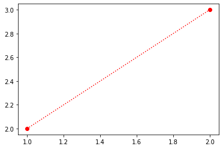

```python
x = [1, 2]
y = [2, 3]

plt.plot(x, y,'o:r')  # 3chars give you: marker type, line type and colour

# for line type characters: https://matplotlib.org/2.1.2/api/_as_gen/matplotlib.pyplot.plot.html
```

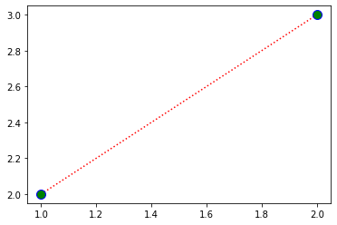

```python
plt.plot(x, y,'o:r',
         ms = 10,   # marker size
         mfc = 'g',  # inside of marker
         mec = 'b')  # mec: outline of marker
```

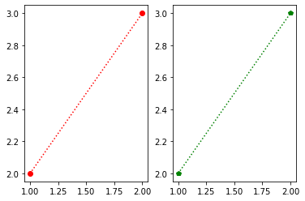

```python
plt.subplot(1, 2, 1)
plt.plot(x, y,'o:r')

plt.subplot(1, 2, 2)
plt.plot(x, y,'p:g')
```

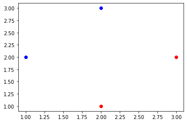

```python
plt.scatter(x, y, color = 'b')
plt.scatter(y, x, color = 'r')
```

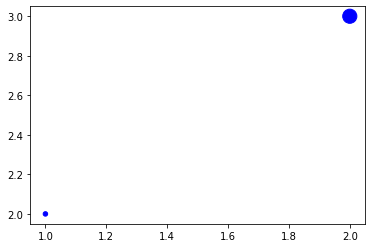

```python
plt.scatter(x, y, s = [20, 200], color = 'b')
```

```
<BarContainer object of 2 artists>
```

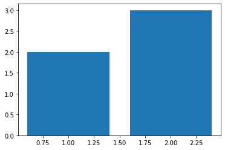

```python
plt.bar(x, y)
```

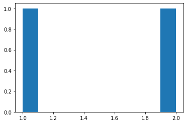

```python
plt.hist(x)
```

```python
import plotly.express as px
```

```python
fig = px.bar([1, 2, 3],
             title = 'Example bar chart',
             labels=dict(index='aaaa'))  # renames heading on hover
fig
```

[interactive chart not shown]

```python
px.line(x, y)
```

[interactive chart not shown]

```python
iris = px.data.iris()
```

## LDA

Latent Dirichlet Allocation

You know a said number of topics are in the document

Start by assigning a word to one of the topics at random

Then for each document count the number of words in each topic

For a given word in a given document:

```
Remove it from document

a. Count occurances of words of each topic, for each document (a score of how much each doc 'likes' each topic)

b. Count occurances of that word for each topic

Multiply (a) and (b). Reassign the removed word to the topic with the highest score
```

Iterate until words stop being reassigned

source: https://www.youtube.com/watch?v=Cpt97BpI-t4

## Another way of stating the above for LDA

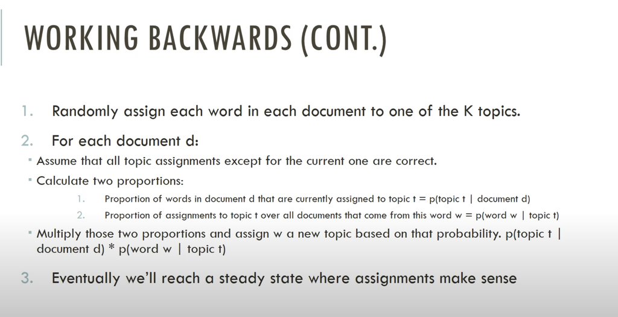

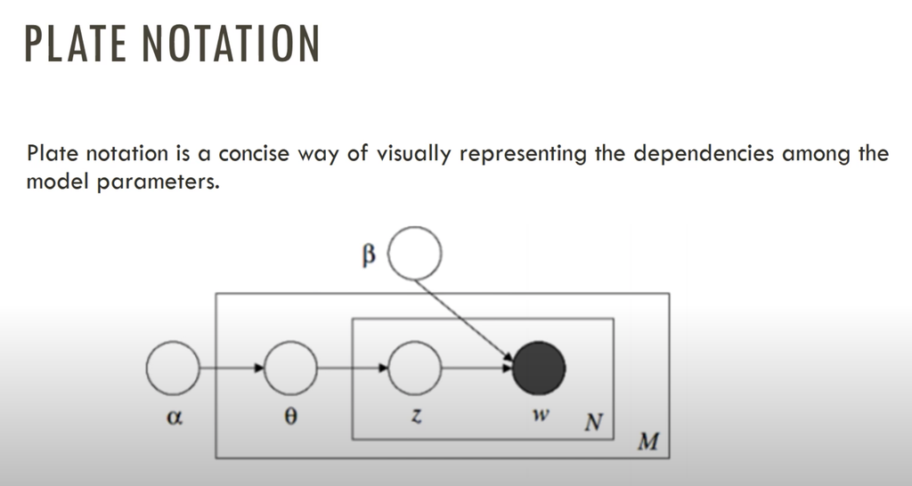

source: https://www.youtube.com/watch?v=DWJYZq_fQ2A

## LCA

latent class analysis

Is a form of finite mixture model (FMM)

Essentially tries to predict which class soemthing is in, based on observed variables. And is unsupervised

Like factor analysis for discrete variables, instead of continuous

Classifies according to maximum likelihood of class membership

A class is characterized by a pattern of conditional probabilities that indicate the chance that variables take on certain values.

Observed variables are independent

Eg: symptoms a-d have been measured in a range of patients with diseases X, Y, and Z, and that disease X is associated with the presence of symptoms a, b, and c, disease Y with symptoms b, c, d, and disease Z with symptoms a, c and d.

The LCA will attempt to detect the presence of latent classes (the disease entities), creating patterns of association in the symptoms.

On LCA vs clustering: https://stats.stackexchange.com/questions/122213/latent-class-analysis-vs-cluster-analysis-differences-in-inferences

### More on finite mixture models vs clustering

FMM fits model to each 'class' (ie, thhe cluster), whihchh includes the probabilistic distribution around the centroid

because its probabilistic, 'classes' can overlap. giving individuals probabilities of belonging to different classes

source: https://centerstat.org/whats-the-difference-between-finite-mixture-models-and-cluster-analysis/

### FMM process

One will fit a finite mixture model using maximum likelihood estimation, in which the number of classes must be declared as part of the model specification. Thus, the analyst will fit a model with 1 class, then 2 classes, then 3, etc., and then compare the fit of these models to try to determine the optimal number of classes. Various approaches to determining the optimal number of classes can be considered but they generally fall into three primary categories: likelihood ratio tests, information criterion, and entropy statistics. Let’s consider each in turn. (And, yes, there are Bayesian approaches to this problem too, but they aren’t widely used in practice so we won’t be addressing those).

source: https://centerstat.org/class-enumeration/